# Simple ploidy estimate demo

James McFarland

7/9/2021

## Load data

```r
CCLE.segment.cn <- load.from.taiga(data.name='public-21q2-110d', data.version=13, data.file='CCLE_segment_cn')
```

```
## Fetching https://cds.team/taiga/api/dataset/public-21q2-110d/13
## Status 200
## loading cached data version from  /Users/jmmcfarl/.taiga/public-21q2-110d_13.toc
```

```r
CCLE.ABSOLUTE.combined.table <- load.from.taiga(data.name='ccle-absolute-cn', data.version=5, data.file='CCLE_ABSOLUTE_combined_table')
```

```
## Fetching https://cds.team/taiga/api/dataset/ccle-absolute-cn/5
## Status 200
## loading cached data version from  /Users/jmmcfarl/.taiga/ccle-absolute-cn_5.toc
```

## Defining the function

This function takes as input the segmented copy number data (with relative CN estimates) and returns a table with ploidy estimates for each line (and some other stats)

You can use these `est_ploidy` values to convert relative CN to absolute in the segmented profile like this:

`CN_seg_df %<>% mutate(abs_CN = Segment_Mean*est_ploidy)`

and for the gene level CN (which is in log2(1+x) units) you can do this:

`gene_abs_CN = (2^gene_rel_CN-1) * est_ploidy`

```r
#' Title
#'
#' @param CN_seg_df: segmented CN file formatted as in DepMap release files
#' @param fig_dir: path to directory to print out figs
#' @param return_fig: Bool to indicate whether to print out fig to console (for testing)
#' @param CCLE_ABS_TABLE: table of ABSOLUTE stats (used for making diagnostic plots only)
#' @param min_ploidy: minimum ploidy values tested
#' @param max_ploidy: max ploidy value tested
#' @param n_ploidy_gridvals number of grid points used to test ploidy vals
#' @param diploid_prior_weight strength of prior biasing towards diploidy ploidy
#'
#' @return
#' @export
#'
#' @examples
est_ploidy_simple <- function(CN_seg_df, fig_dir = NULL, return_fig = FALSE, CCLE_ABS_TABLE = NULL, min_ploidy = 1.25, max_ploidy = 10, n_ploidy_gridvals = 500,
                              diploid_prior_weight = 0.0025) {

  poss_sc_facs <- seq(from = min_ploidy, to = max_ploidy, length.out = n_ploidy_gridvals)

  #create simple prior to slightly bias towards diploid
  tent_fn <- function(x, cp = 2, slope = diploid_prior_weight, min_prob = 0.1) {
    y <- 1+(x-cp)*slope
    gt <- x > cp
    y[gt] <- 1-(x[gt]-cp)*slope
    y[y < min_prob] <- min_prob
    return(y)
  }
  prior <- tent_fn(poss_sc_facs)

  cls <- unique(CN_seg_df$DepMap_ID)
  simp_ploidy_res <- ldply(cls, function(targ) {
    df <- CN_seg_df %>% filter(DepMap_ID == targ) %>% mutate(width = End - Start)

    scaled_vals <- df$Segment_Mean %o% poss_sc_facs
    err <- colSums(df$width * (scaled_vals - round(scaled_vals))^2)/sum(df$width)
    res <- tibble(sc = poss_sc_facs, err = err, p = prior) %>%
      mutate(post = p*(1-err))

    #find scaling factor that maximizes the 'posterior'
    best_sc <- res %>% arrange(dplyr::desc(post)) %>% head(1)

    #compute the residual var of the integer CN fit
    df %<>% mutate(resid = Segment_Mean*best_sc$sc - round(Segment_Mean*best_sc$sc)) #calculate residual from integer model
    rvar <- weightedVar(df$resid, df$width)

    #make fig if neeeded
    if (!is.null(fig_dir) | return_fig) {
      print(targ)
      abs_ploidy <- CCLE_ABS_TABLE %>% filter(DepMap_ID == targ) %>% pull(ploidy)
      abs_sc <- CCLE_ABS_TABLE %>% filter(DepMap_ID == targ) %>% pull(`Subclonal genome fraction`)
      g1 <- ggplot(res, aes(sc, 1-err)) +
        geom_point() +
        geom_point(aes(sc, post), color = 'blue') +
        geom_point(data = best_sc, color = 'red', size = 2) +
        xlim(0,10)
      g2 <- ggplot(df, aes(x = Segment_Mean*best_sc$sc, y = ..density.., weight = width)) +
        geom_histogram(bins = 200) +
        geom_vline(xintercept = seq(0, 10, by = 1), linetype = 'dashed') +
        xlim(0, 10) +
        ggtitle(sprintf('Inferred ploidy, %s, %.2f, resid-var: %.4f', unique(df$Source), best_sc$sc, rvar))
      g3 <- ggplot(df, aes(x = Segment_Mean*abs_ploidy, y = ..density.., weight = width)) +
        geom_histogram(bins = 200) +
        geom_vline(xintercept = seq(0, 10, by = 1), linetype = 'dashed') +
        xlim(0, 10) +
        ggtitle(sprintf('ABS ploidy, Sc frac: %.2f, ploidy: %.2f', abs_sc, abs_ploidy))
      p <- cowplot::plot_grid(g1, g2, g3, ncol = 1)

      if (return_fig) {
        print(p)
      }
      if (!is.null(fig_dir)) {
      ggsave(file.path(fig_dir, paste0(targ, '_simple_ploidy.png')), plot = p, height = 9, width = 5)
      }
    }

    tibble(DepMap_ID = targ,
           min_err = best_sc$err,
           est_ploidy = best_sc$sc,
           resid_var = rvar,
           Source = unique(df$Source))
  })
}
```

## Tests

An example where both simple ploidy and ABSOLUTE ploidy estimates agree well

Note, in these plots the black line represents the goodness of fit, and the blue is a penalized fit (using a loose prior favoring diploid genomes)

```r
targ_CL <- 'ACH-000522'
est_ploidy_simple(CCLE.segment.cn %>% filter(DepMap_ID == targ_CL),
                  return_fig = TRUE,
                  CCLE_ABS_TABLE = CCLE.ABSOLUTE.combined.table)
```

```
## [1] "ACH-000522"
```

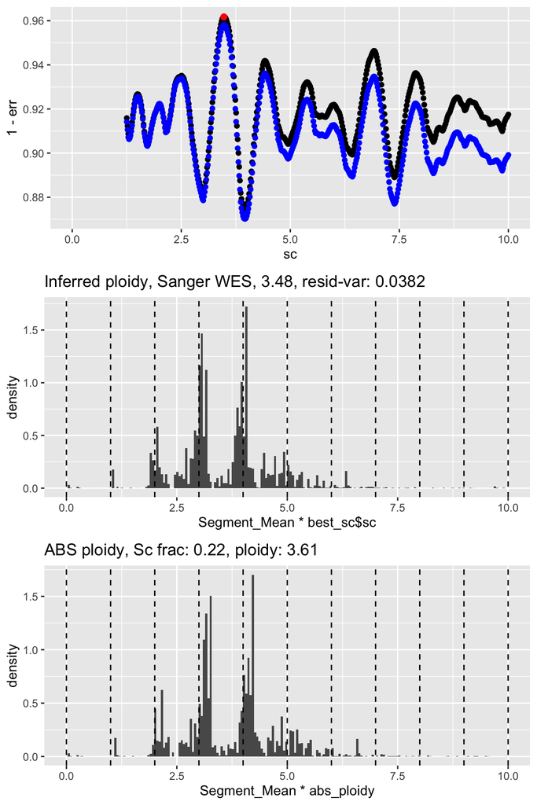

This example the simple estimate seems to get it right while the ABSOLUTE one seems to get it wrong. (based on just looking at this plot).

```r
targ_CL <- 'ACH-000773'
est_ploidy_simple(CCLE.segment.cn %>% filter(DepMap_ID == targ_CL),
                  return_fig = TRUE,
                  CCLE_ABS_TABLE = CCLE.ABSOLUTE.combined.table)
```

```
## [1] "ACH-000773"
```

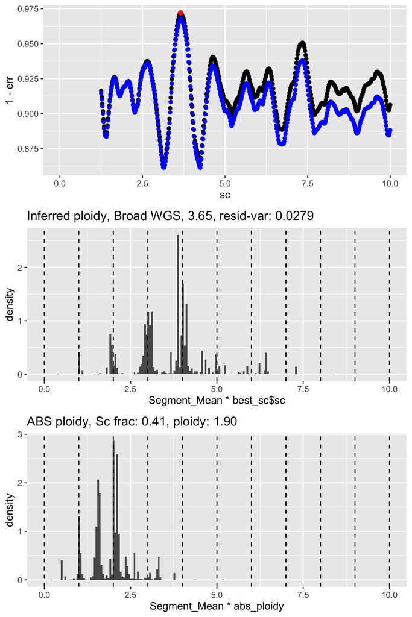

Not sure either is right here

```r
targ_CL <- 'ACH-000862'
est_ploidy_simple(CCLE.segment.cn %>% filter(DepMap_ID == targ_CL),
                  return_fig = TRUE,
                  CCLE_ABS_TABLE = CCLE.ABSOLUTE.combined.table)
```

```
## [1] "ACH-000862"
```

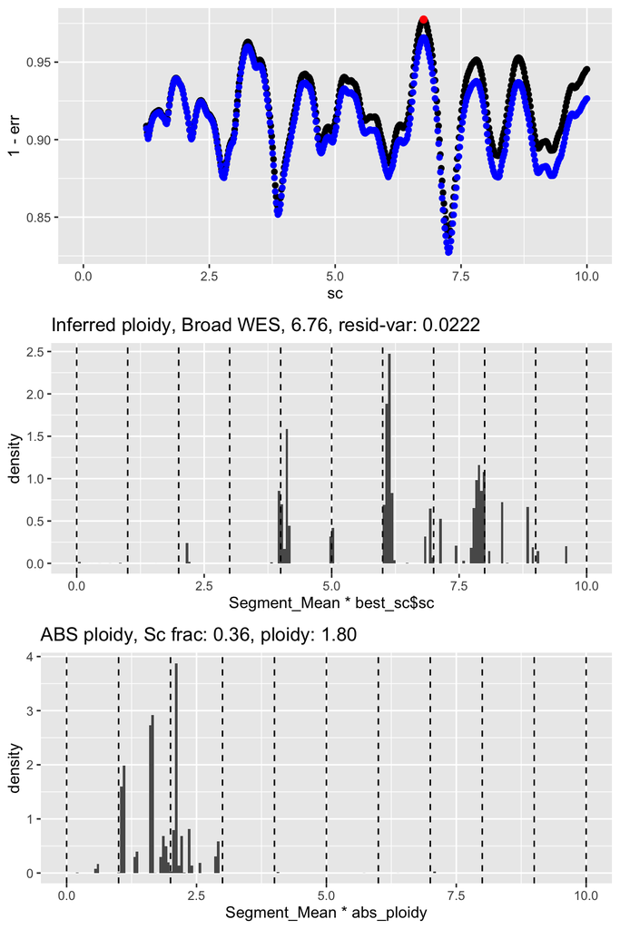

## GLobal comparisons

Running across all cell lines, we can then compare the ploidy estimates with what CCLE ABSOLUTE found. Overall there is *OK* agreement. Most of the disagreement comes either when the ABSOLUTE “call status” is null (maybe failed to return a good soln?), or when ABSOLUTE thought there was a high subclonal genome fraction. That makes sense because if purity = 1, and subclonal fraction is 0 they should agree. Question is then, is there actually higher subcloncal fraction in these cases, or higher ploidy (like the simple method tends to think)..

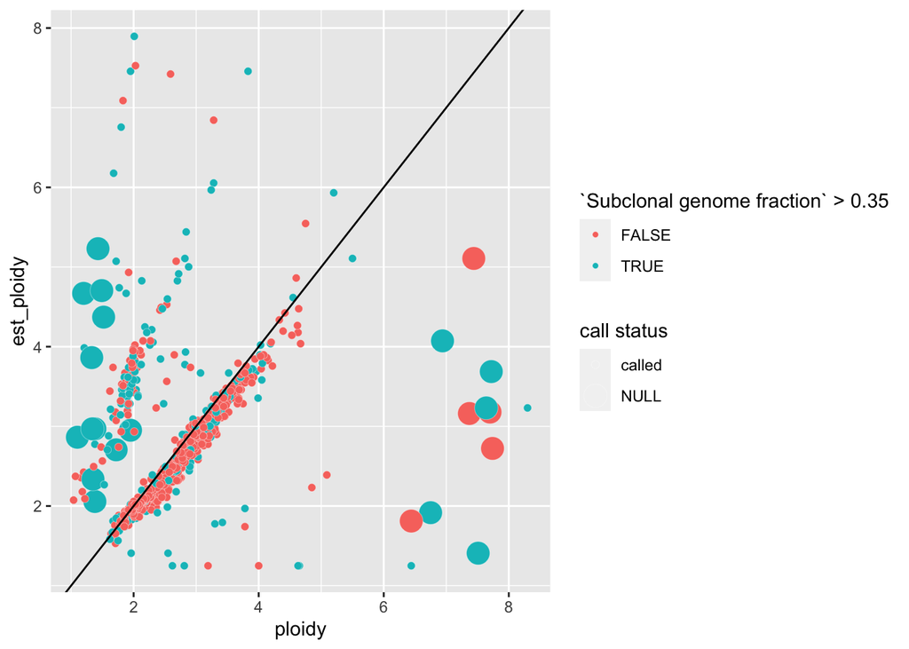

```r
simp_ploidy_res <- est_ploidy_simple(CCLE.segment.cn)

comb <- inner_join(CCLE.ABSOLUTE.combined.table, simp_ploidy_res, by = 'DepMap_ID')

ggplot(comb, aes(ploidy, est_ploidy, fill = `Subclonal genome fraction` > 0.35, size = `call status`)) +
  geom_point(pch = 21, color = 'white', stroke = 0.1) +
  geom_abline()
```

```r
with(comb %>% filter(`Subclonal genome fraction` < 0.35, `call status` == 'called'), cor(ploidy, est_ploidy, method = 'spearman'))
```

```
## [1] 0.7289424
```

Disagreement between ploidy estimates increases as the integer-CN model fit gets worse (makes sense)

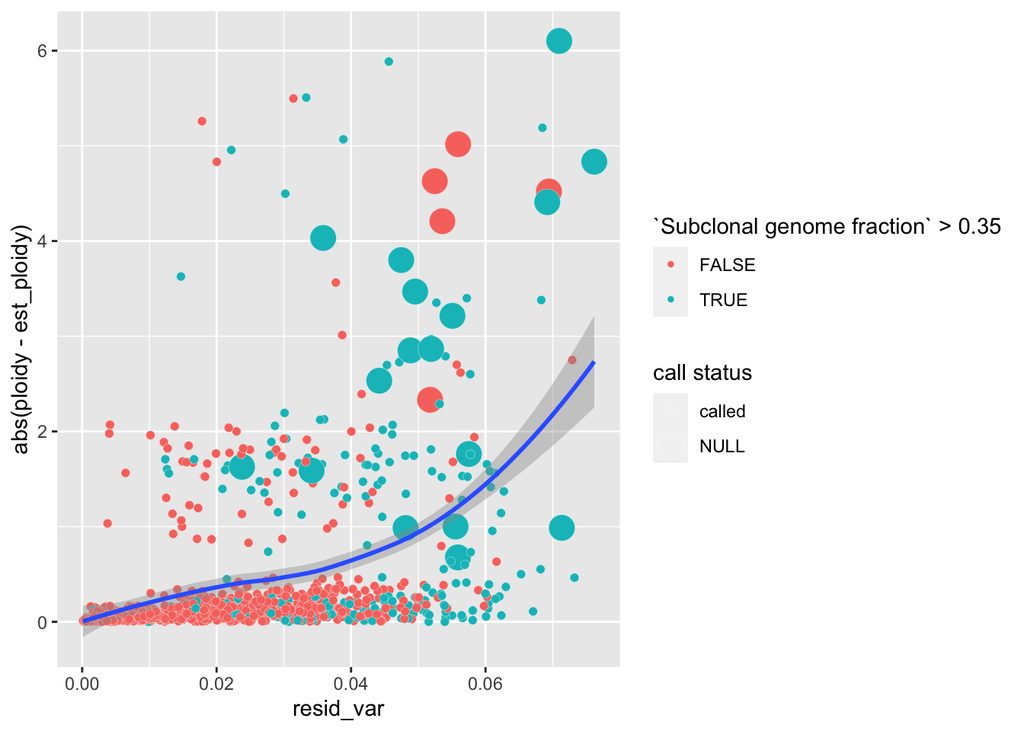

```r
ggplot(comb, aes(resid_var, abs(ploidy-est_ploidy))) +
  geom_point(aes(fill = `Subclonal genome fraction` > 0.35, size = `call status`), pch = 21, color = 'white', stroke = 0.1) +
  geom_smooth()
```